# Пространственные паттерны в отловах птиц 2

## Подготовка данных

Таблицу с численностью отловленных птиц я предлагаю нормировать по общему количеству отловленных птиц каждого вида. То есть, по сути, моделируем вероятность встречи данного вида птиц в данной локации. Но, поскольку в разных точках усилия по отлову были разные, то в качестве технической ковариаты в модель добавим еще данные по catchment efforts. Если я не напутал, то усилия по отлову на разных станциях выглядят вот так.

[output not shown]

Так выглядит карта расположения точек отлова птиц.

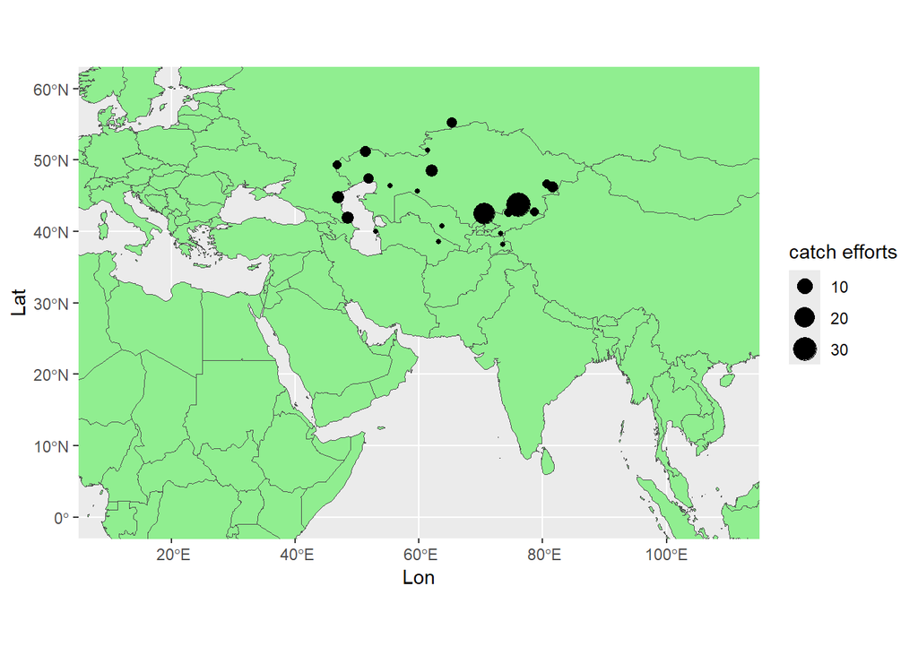

## Модель географической приуроченности видов

Пока мне кажется, что наиболее адекватным методом анализа является канонический корреспондентный анализ (Canonical Correspondence Analysis, CCA, ter Braak, 1987). Выбор именно этого метода обусловлен тем, что в его основе лежит мера расстояния (Chi_sq Distance), которая характеризует степень отклонения от нулевой модели, под которой подразумевается независимость столбцов и строк матрицы данных. Проще говоря, что виды не ощущают различия в локациях станций. В качестве ковариат в анализе взяты географические координаты (Lon, Lat) и активность отлова. Логика анализа сводится к тому, что значимая ковариата должна сильнее всего отклонять строку или колонку от нулевой модели. Для проверки статической значимости модели, в целом, отдельных канонических осей, а также двух предикторов, использован пермутационный метод, описанный в Borcard et al., 2011. Было проведено 9999 актов пермутации.

Полученные в анализе три канонические оси в сумме описывают 42.4% общей инерции (of total Inertia). Сама модель была статистически значимой.

| term | df | ChiSquare | statistic | p.value |
| --- | --- | --- | --- | --- |
| Model | 3 | 1.249163 | 4.656469 | 1e-04 |
| Residual | 19 | 1.699005 | NA | NA |

При этом статистически значимой были первая и вторая канонические оси (CCA1 и CCA2), которые описывают 35.9% общей инерции. Эти оси связаны как с долготой, так и с широтой (см. рисунок).

| term | df | ChiSquare | statistic | p.value |
| --- | --- | --- | --- | --- |
| CCA1 | 1 | 0.6487543 | 7.255029 | 0.0001 |
| CCA2 | 1 | 0.4089373 | 4.573151 | 0.0003 |
| CCA3 | 1 | 0.1914713 | 2.141226 | 0.0567 |
| Residual | 19 | 1.6990052 | NA | NA |

| term | df | ChiSquare | statistic | p.value |
| --- | --- | --- | --- | --- |
| n | 1 | 0.1993735 | 2.229596 | 0.0490 |
| Lat | 1 | 0.3592429 | 4.017419 | 0.0002 |
| Lon | 1 | 0.4880641 | 5.458027 | 0.0001 |
| Residual | 19 | 1.6990052 | NA | NA |

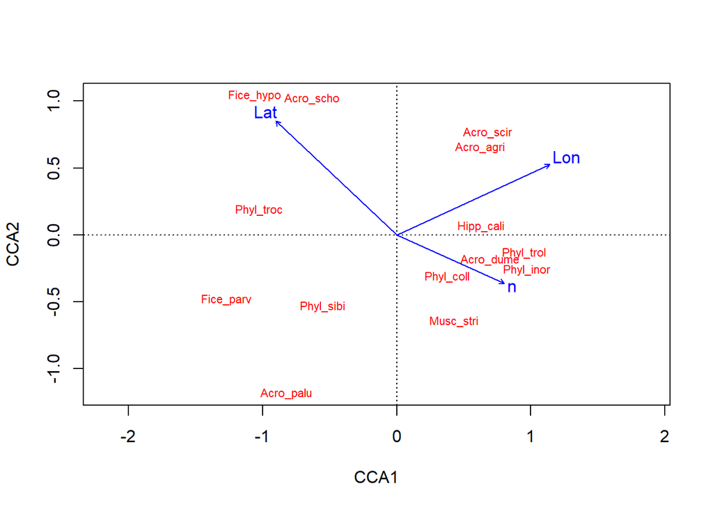

**Fig. ++**. Ординация видов в канонических осях, заданных географическими координатами расположения станций кольцевания

Полученная ординация видов позволяет разделить их на четыре группы:

- 1 группа - виды, располагающиеся в I квадранате ординации. Это преимущественно Северо-Восточные и Юго-Восточные.
- 2 группа - виды, располагающиеся во II квадранате ординации. Это, скорее Северо-Западные и Юго-Западные.
- 3 группа - виды, располагающиеся в III квадранате ординации. Это виды Северо-Западные и Юго-Западные.
- 4 группа - виды, располагающиеся в IV квадранате ординации. Это, скорее, Юго-Восточные виды.

Проще говоря, группы 1 и 4 - это, скорее, виды звосточные, а 3 и 2 группы - это, скорее, западные.

## Карты отловов группы 1 (Восточная группа)

Здесь и далее приводятся только ненулевые точки отловов. Размер точки пропорционален вероятности отлова. Серым залиты те страны, в которых происходит зимовка. Важно! Я выбирал страны абсолютно формально. Например, Юго-Восточной Азией считал все, что считает таковой Википедия.

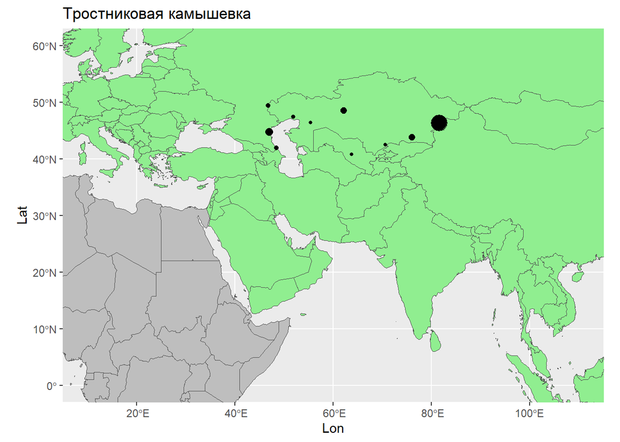

Ник! Тут есть подозрение на ошибку в данных. Этот вид попал в данную группу только из-за высокой численности отловов на одной станции Alakol Lake, KZ. Если это не фейк, то это какая-то сумасшедшая птица. Она либо еще где-то зимует, кроме Африки, или у нее какой-то очень странный коридор миграции.

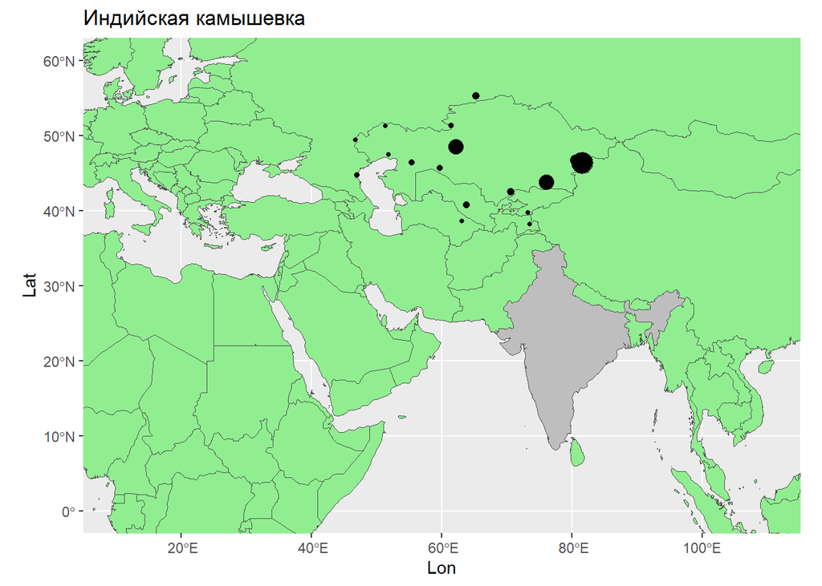

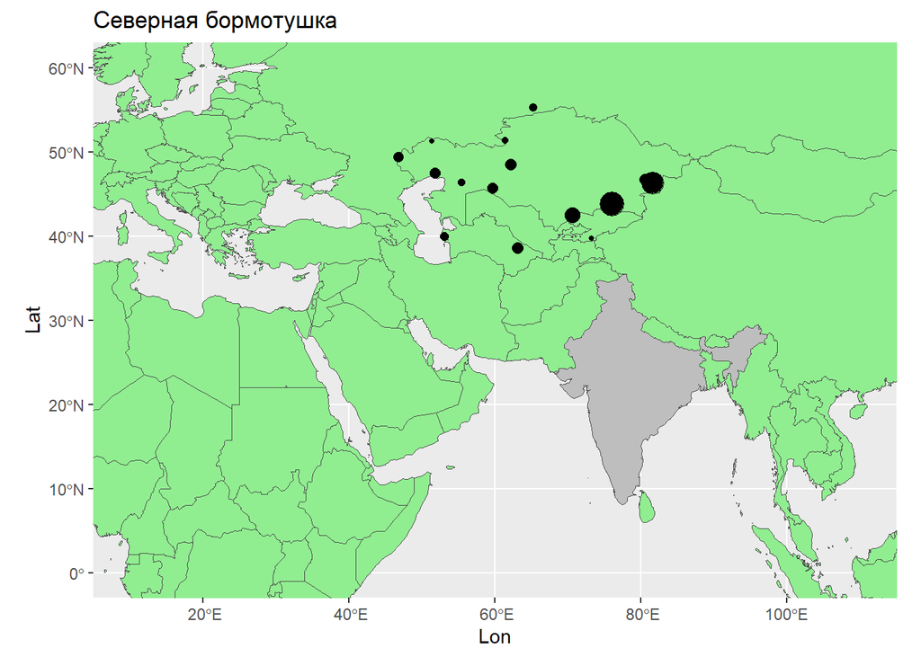

## Карты отловов группы 4 (Восточная группа)

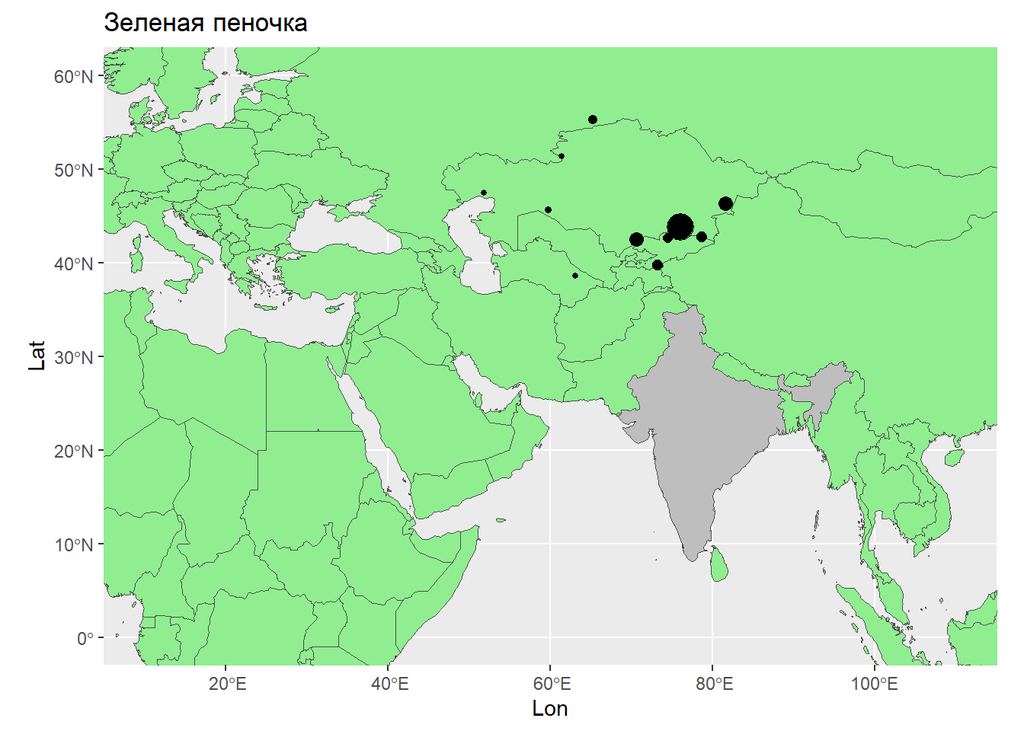

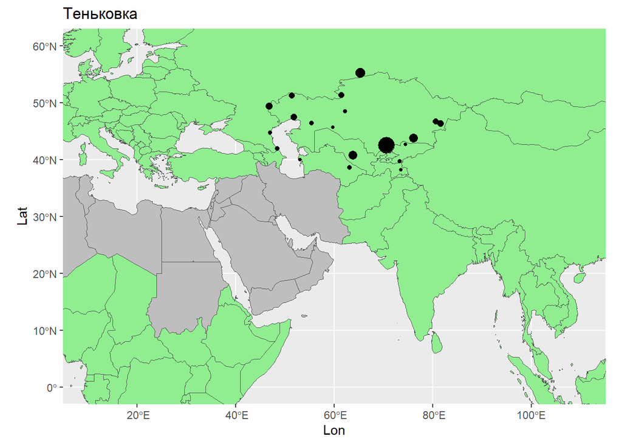

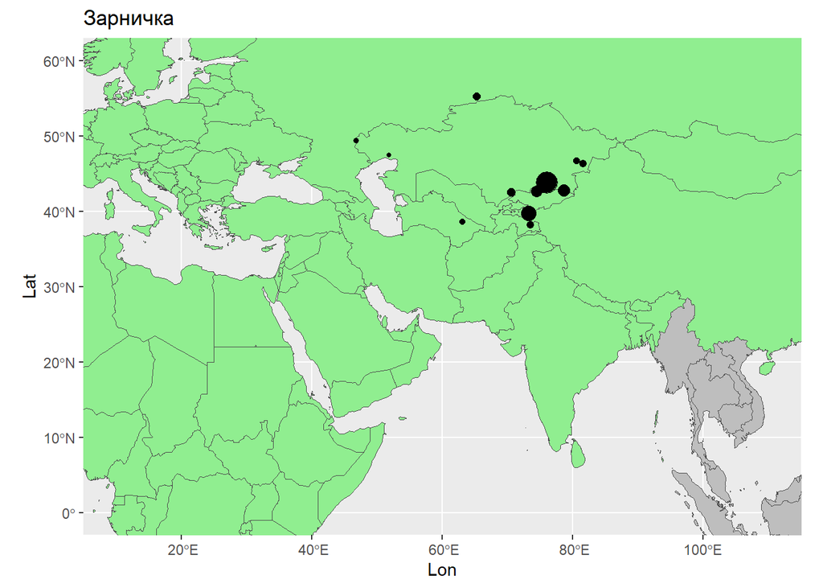

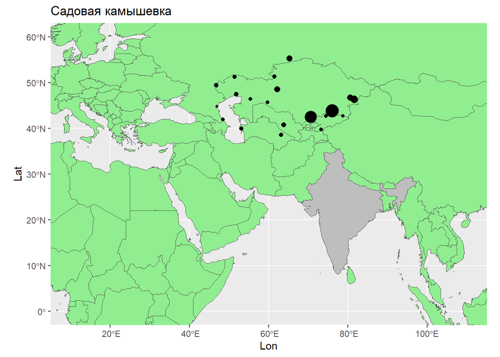

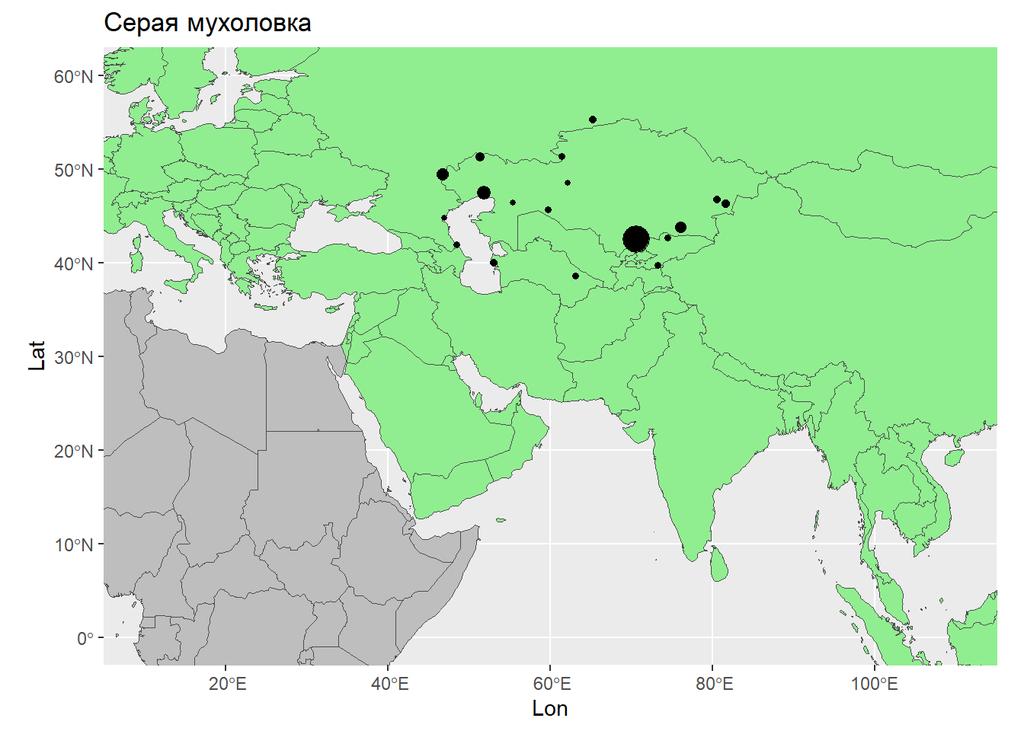

Тоже какая-то дурная птица.

## Карты отловов группы 2 (Западная група)

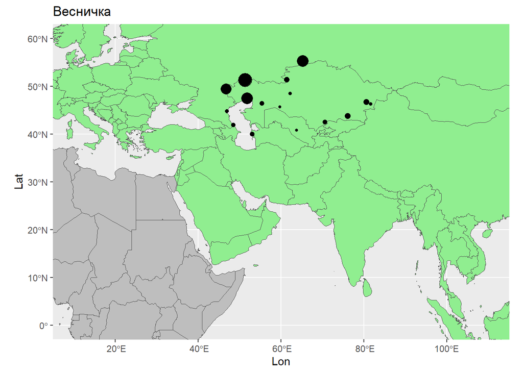

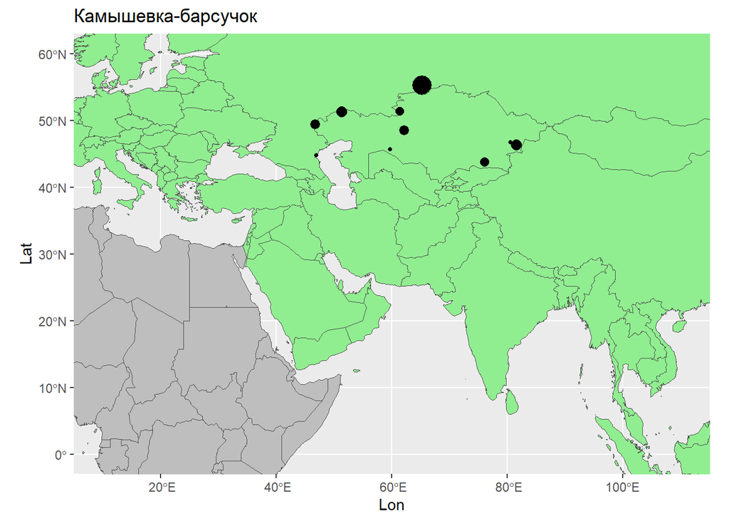

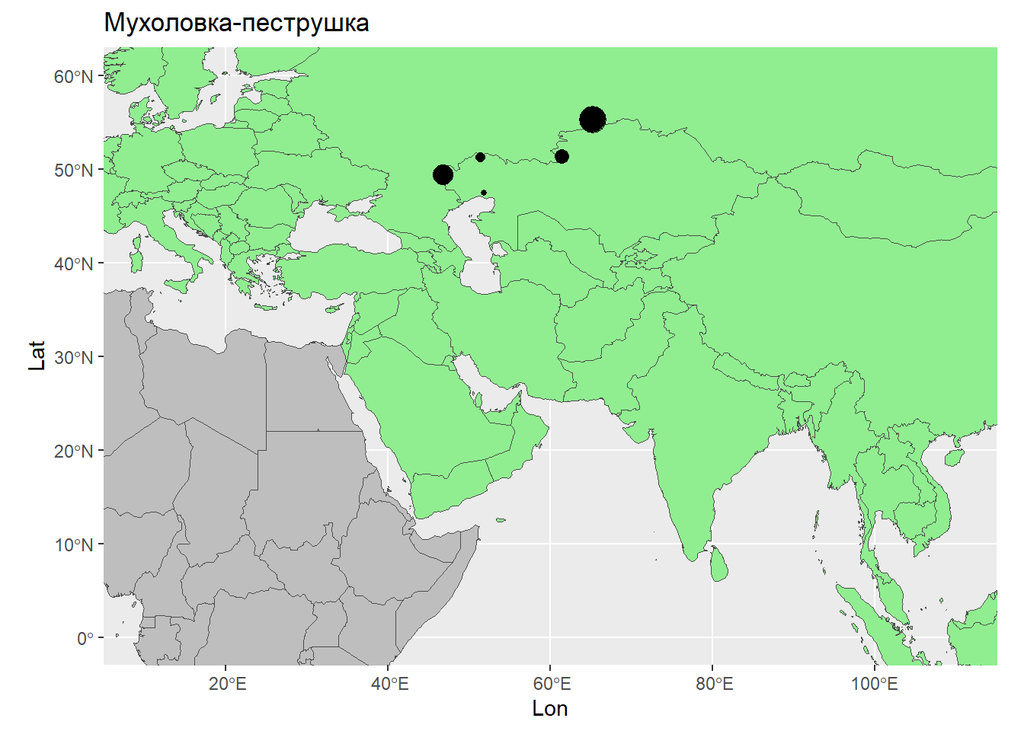

## Карты отловов группы 3 (Западная група)

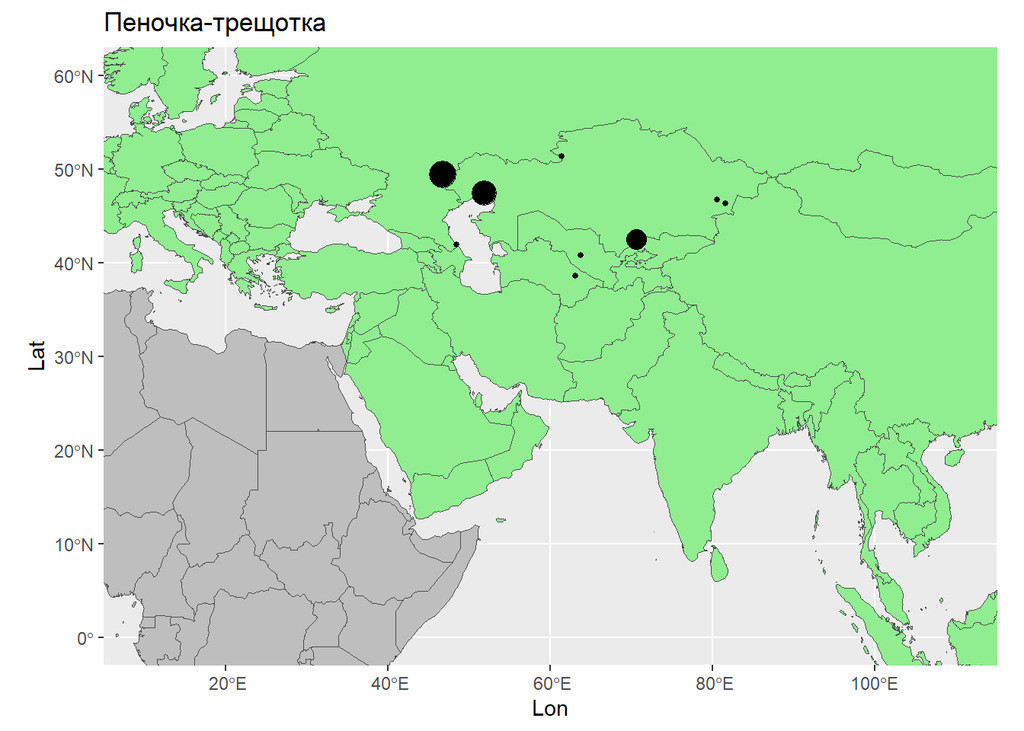

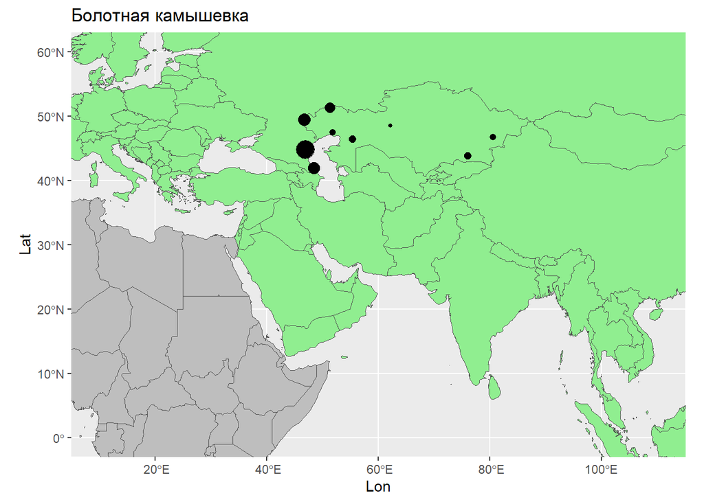

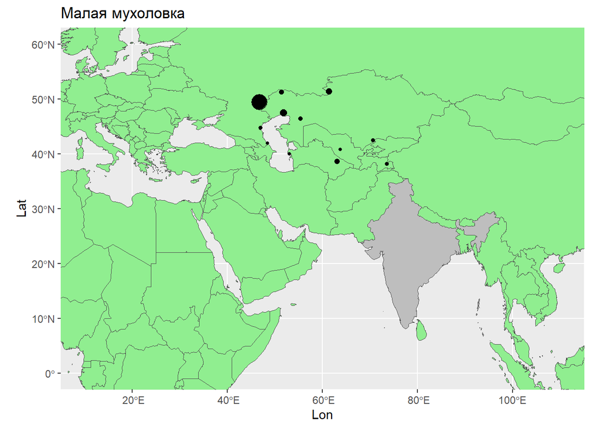

Аналогичная история. Этот вид попал в западную группу по вине одной станции отлова.